# Eliana_Project

## Analysis

All Python libraries utilized for this project are shown below.

```python
import pandas as pd
import numpy as np
import csv
import seaborn as sns
import matplotlib.pyplot as plt
```

### Data Information

```python
df_0 = pd.read_csv('Indicators_of_Anxiety_or_Depression_Based_on_Reported_Frequency_of_Symptoms_During_Last_7_Days.csv')
```

```python
df_0.shape
```

```
(16794, 14)
```

```python
df_0.info()
```

```
<class 'pandas.core.frame.DataFrame'>
RangeIndex: 16794 entries, 0 to 16793
Data columns (total 14 columns):
 #   Column                  Non-Null Count  Dtype
---  ------                  --------------  -----
 0   Indicator               16794 non-null  object
 1   Group                   16794 non-null  object
 2   State                   16794 non-null  object
 3   Subgroup                16794 non-null  object
 4   Phase                   16794 non-null  object
 5   Time Period             16794 non-null  int64
 6   Time Period Label       16794 non-null  object
 7   Time Period Start Date  16794 non-null  object
 8   Time Period End Date    16794 non-null  object
 9   Value                   16087 non-null  float64
 10  Low CI                  16087 non-null  float64
 11  High CI                 16087 non-null  float64
 12  Confidence Interval     16087 non-null  object
 13  Quartile Range          11017 non-null  object
dtypes: float64(3), int64(1), object(10)
memory usage: 1.8+ MB
```

The original CSV file for the *Indicators of Anxiety or Depression Based on Reported Frequency of Symptoms During the Last 7 Days* contains fourteen variables. Several columns represent demographic classifications, including Group, State, and Subgroup. The dataset also includes multiple time-related variables: Phase, Time Period, Time Period Label, Time Period Start Date, and Time Period End Date. They describe the survey wave in which each observation was collected. Most variables contain the full 16,794 entries. However, four estimation-related columns—Value, Low CI, High CI, and Confidence Interval—are missing exclusively for observations that represent non-state groups. In other words, rows associated with national-level categories(such as “United States,” “By Age,” or “By Race/Ethnicity”) are far more likely to lack published estimates and confidence intervals. This indicates that the missingness is not random but instead reflects structural features of the survey design. The Household Pulse Survey prioritizes state-level estimates and does not always compute or release estimates for every demographic subgroup at the national level. When sample sizes are insufficient or a subgroup is not included in the model for a particular phase, the survey omits the estimate entirely. These omissions lead to gaps in the four estimation columns for non-state groups, while state-specific rows remain largely complete.

```python
data_dict = pd.DataFrame({
    'Variable Name': df_1.columns,
    'Data Type': df_1.dtypes.astype(str)
})
definitions = {
    'Indicator': 'Type of mental health indicator measured (e.g., anxiety, depression).',
    'Group': 'Population subgroup being analyzed (e.g., age, gender, race, education).',
    'State': 'U.S. state or territory where data was collected.',
    'Subgroup': 'Specific demographic within the broader group (e.g., 18–29 years, female).',
    'Phase': 'Time period or survey phase (e.g., Phase 3.1).',
    'Time Period': 'Specific date range of data collection.',
    'Time Period Start Date': 'The specific start date of data collection.',
    'Time Period End Date': 'The specific end date of data collection.',
    'Value': 'Estimated percentage of respondents reporting the indicator during the last 7 days.',
    'Low CI': 'Lower bound of the 95% confidence interval for Value.',
    'High CI': 'Upper bound of the 95% confidence interval for Value.',
    'Quartile Range': 'Relative quartile category of Value (Q1–Q4). May be missing or derived.',
    'Confidence Interval': 'Reported range of uncertainty around Value (may be redundant).',
}
data_dict['Definition'] = data_dict['Variable Name'].map(definitions).fillna('No definition available. Please review.')
```

```python
data_dict
```

|  | Variable Name | Data Type | Definition |
| --- | --- | --- | --- |
| Indicator | Indicator | object | Type of mental health indicator measured (e.g.... |
| Group | Group | object | Population subgroup being analyzed (e.g., age,... |
| State | State | object | U.S. state or territory where data was collected. |
| Subgroup | Subgroup | object | Specific demographic within the broader group ... |
| Phase | Phase | object | Time period or survey phase (e.g., Phase 3.1). |
| Time Period | Time Period | int64 | Specific date range of data collection. |
| Time Period Start Date | Time Period Start Date | datetime64[ns] | The specific start date of data collection. |
| Time Period End Date | Time Period End Date | datetime64[ns] | The specific end date of data collection. |
| Value | Value | float64 | Estimated percentage of respondents reporting ... |
| Low CI | Low CI | float64 | Lower bound of the 95% confidence interval for... |
| High CI | High CI | float64 | Upper bound of the 95% confidence interval for... |
| Confidence Interval | Confidence Interval | object | Reported range of uncertainty around Value (ma... |
| Quartile Range | Quartile Range | object | Relative quartile category of Value (Q1–Q4). M... |

### Data Analysis

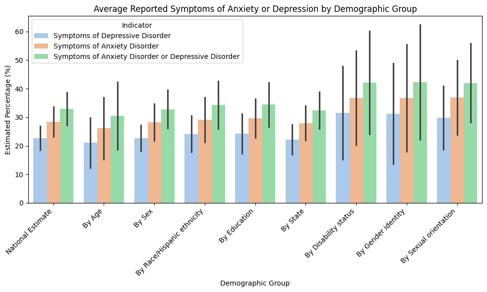

```python
plt.figure(figsize=(10,6))
sns.barplot(
    data=df_1,
    x="Group",
    y="Value",
    hue="Indicator",     # diff colors for indicators
    errorbar = 'sd',             # shows the standard deviation as error bars
    palette="pastel"
)
plt.title("Average Reported Symptoms of Anxiety or Depression by Demographic Group")
plt.xlabel("Demographic Group")
plt.ylabel("Estimated Percentage (%)")
plt.xticks(rotation=45, ha="right")

plt.legend(title="Indicator")
plt.tight_layout() #make its look a lil nicer
plt.show()
```

Each bar represents the mean percentage of adults reporting symptoms within each demographic group. The colors represent different mental health indicators as shown in the top left legend.

### Analysis of Anxiety by Subgroups

```python
excluded_subgroups = [
    "With disability", "Without disability",
    "Gay or lesbian", "Bisexual", "Straight", "Something else",
    "Transgender", "Not transgender",
    "Has health insurance", "Does not have health insurance",
    "Vaccinated", "Not vaccinated"
]
```

Several subgroup categories were excluded to avoid inappropriate comparisons. Specifically, disability status, sexual orientation, gender identity, health insurance status, and vaccination status were removed because these categories are not directly comparable to socioeconomic, race, or age-based subgroups.

```python
df_2 = df_1[~df_1["Subgroup"].isin(excluded_subgroups)]
```

```python
anxiety_df = df_2[df_2["Indicator"] == "Symptoms of Anxiety Disorder"]
```

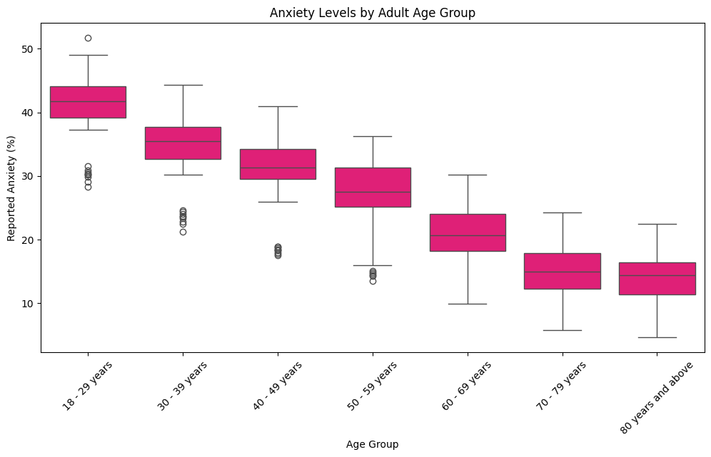

```python
age_anxiety = anxiety_df[anxiety_df["Group"] == "By Age"]

plt.figure(figsize=(12,6))
sns.boxplot(data= age_anxiety, x="Subgroup", y="Value",color= "#FF0074")
plt.xticks(rotation=45)
plt.title("Anxiety Levels by Adult Age Group")
plt.ylabel("Reported Anxiety (%)")
plt.xlabel("Age Group")

plt.show()
```

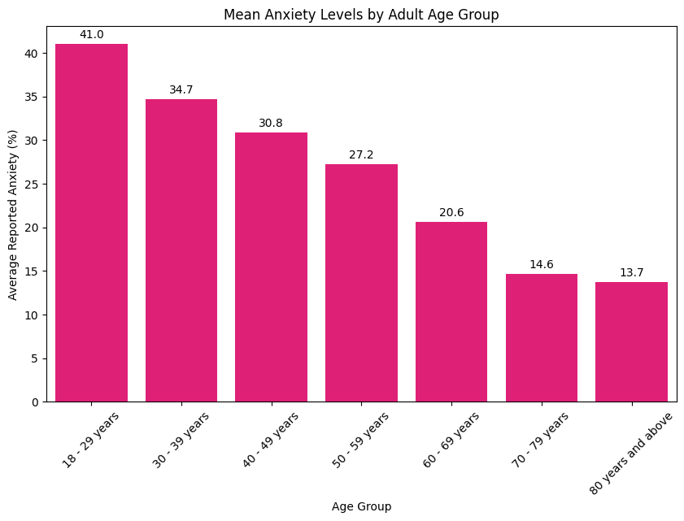

```python
age_means = age_anxiety.groupby("Subgroup")["Value"].mean().reset_index()

plt.figure(figsize=(10,6))
ax = sns.barplot(
    data=age_means,
    x="Subgroup",
    y="Value",
    color="#FF0074"
)

plt.xticks(rotation=45)
plt.title("Mean Anxiety Levels by Adult Age Group")
plt.xlabel("Age Group")
plt.ylabel("Average Reported Anxiety (%)")

ax.bar_label(
    ax.containers[0],
    fmt="%.1f",
    padding=3
)
plt.show()
```

This bar chart aligns with the pattern shown in the previous boxplot: average anxiety levels decrease with age. The mean anxiety percentages align with the medians and distributions from the earlier graph. Anxiety was highest among adults 18–29 and progressively lower in older age groups. The chart summarizes this trend.

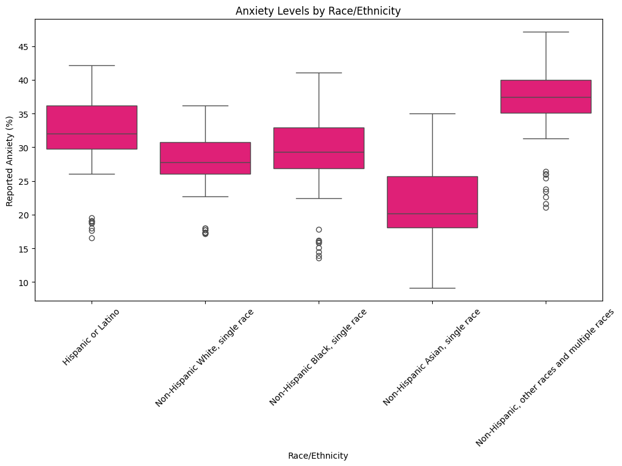

```python
race_df = anxiety_df[anxiety_df["Group"] == "By Race/Hispanic ethnicity"]

plt.figure(figsize=(12,6))
sns.boxplot(data=race_df, x="Subgroup", y="Value",color= "#FF0074")
plt.xticks(rotation=45)
plt.title("Anxiety Levels by Race/Ethnicity")
plt.ylabel("Reported Anxiety (%)")
plt.xlabel("Race/Ethnicity")
plt.show()
```

The boxplots above show the anxiety levels across racial and ethnic groups. Hispanic or Latino adults and Non-Hispanic adults of "other races and multiple races" show the highest anxiety levels, with higher medians and wider spreads. Non-Hispanic Asian adults report the lowest anxiety levels overall, with a much lower median and wider distribution. Non-Hispanic White and Non-Hispanic Black adults fall in between, with Non-Hispanic White having a smaller spread and a lower median. Overall, the graph shows meaningful racial and ethnic differences, with some groups experiencing substantially higher anxiety than others.

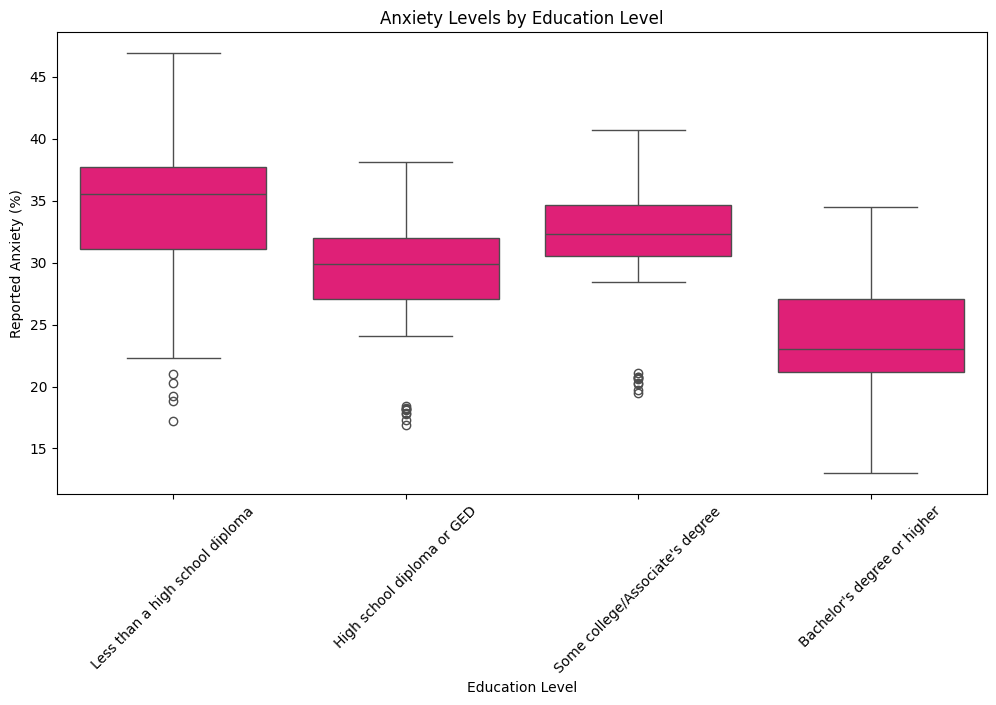

```python
edu_df = anxiety_df[anxiety_df["Group"] == "By Education"]

plt.figure(figsize=(12,6))
sns.boxplot(data = edu_df, x="Subgroup", y="Value",color= "#FF0074")
plt.xticks(rotation=45)
plt.title("Anxiety Levels by Education Level")
plt.ylabel("Reported Anxiety (%)")
plt.xlabel("Education Level")
plt.show()
```

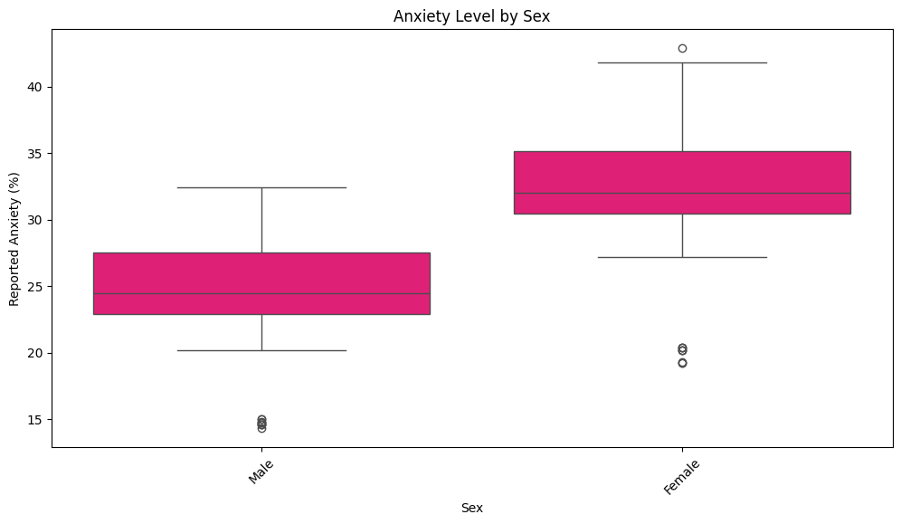

```python
sex_df = anxiety_df[anxiety_df["Group"] == "By Sex"]

plt.figure(figsize = (12,6))
sns.boxplot(data= sex_df, x = "Subgroup", y = "Value",color= "#FF0074")
plt.xticks(rotation =45)
plt.xlabel("Sex")
plt.ylabel("Reported Anxiety (%)")
plt.title("Anxiety Level by Sex")

plt.show()
```

### Data Analysis of Depression by Subgroups

```python
depression_df = df_2[df_2["Indicator"] == "Symptoms of Depressive Disorder"]
```

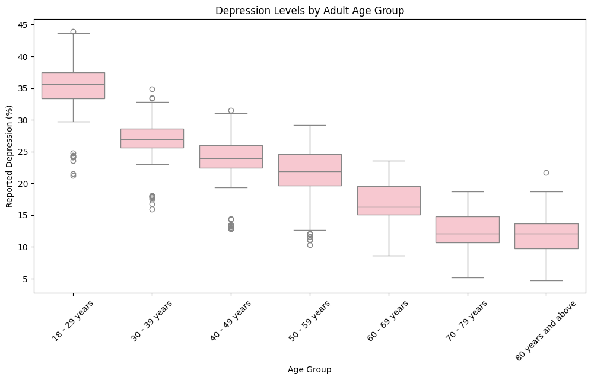

```python
age_dep = depression_df[depression_df["Group"] == "By Age"]

plt.figure(figsize=(12,6))
sns.boxplot(
    data=age_dep,
    x="Subgroup",
    y="Value",
   color= "pink"
)

plt.xticks(rotation=45)
plt.title("Depression Levels by Adult Age Group")
plt.xlabel("Age Group")
plt.ylabel("Reported Depression (%)")

plt.show()
```

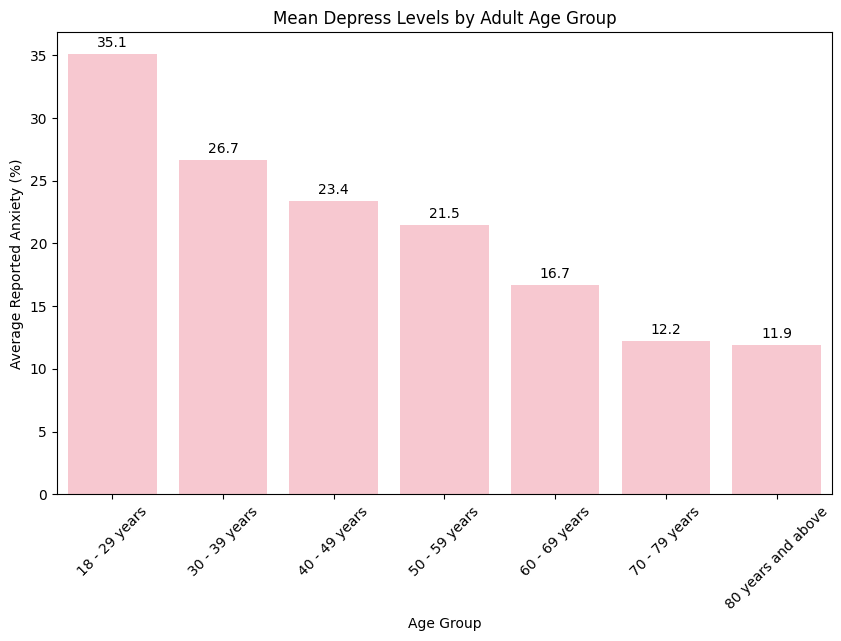

```python
age_means_d = age_dep.groupby("Subgroup")["Value"].mean().reset_index()

plt.figure(figsize=(10,6))
ax = sns.barplot(
    data=age_means_d,
    x="Subgroup",
    y="Value",
    color="Pink"
)

plt.xticks(rotation=45)
plt.title("Mean Depress Levels by Adult Age Group")
plt.xlabel("Age Group")
plt.ylabel("Average Reported Anxiety (%)")

ax.bar_label(
    ax.containers[0],
    fmt="%.1f",
    padding=3
)
plt.show()
```

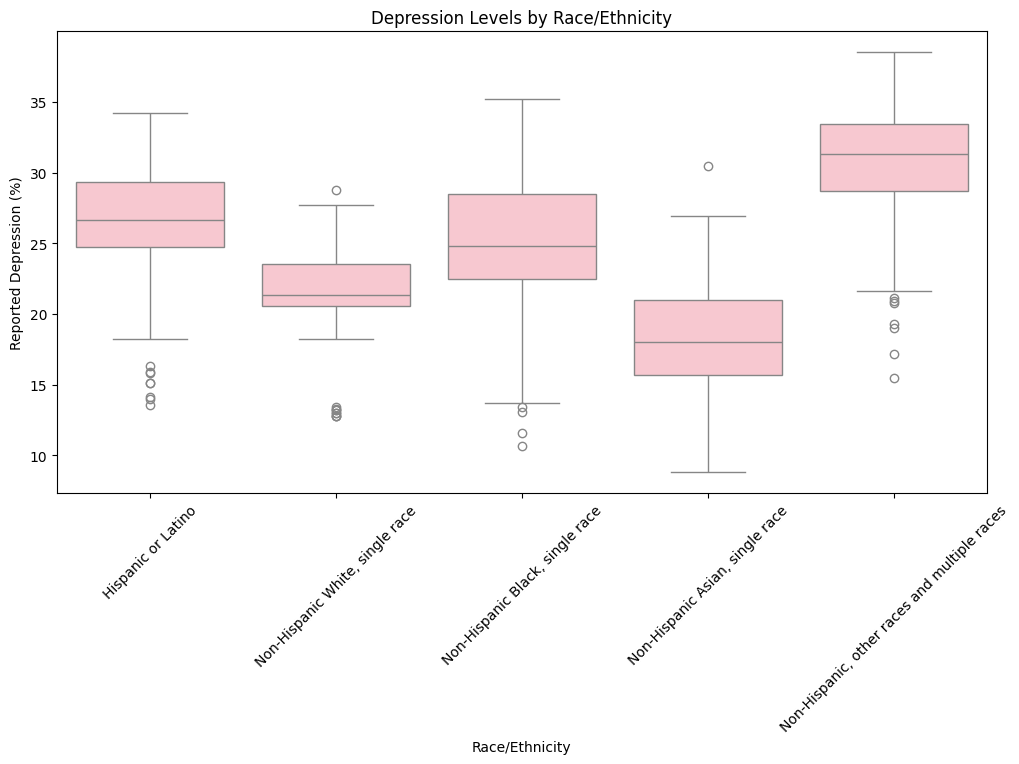

```python
dep_race = depression_df[depression_df["Group"] == "By Race/Hispanic ethnicity"]

plt.figure(figsize=(12,6))
sns.boxplot(
    data=dep_race,
    x="Subgroup",
    y="Value",
    color="pink"
)

plt.xticks(rotation=45)
plt.title("Depression Levels by Race/Ethnicity")
plt.xlabel("Race/Ethnicity")
plt.ylabel("Reported Depression (%)")
plt.show()
```

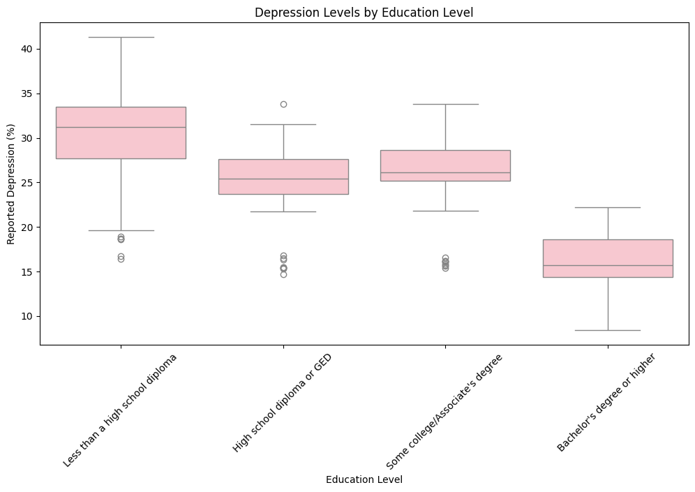

```python
dep_edu = depression_df[depression_df["Group"] == "By Education"]

plt.figure(figsize=(12,6))
sns.boxplot(
    data=dep_edu,
    x="Subgroup",
    y="Value",
    color="pink"
)

plt.xticks(rotation=45)
plt.title("Depression Levels by Education Level")
plt.xlabel("Education Level")
plt.ylabel("Reported Depression (%)")
plt.show()
```

Depression levels decrease as educational attainment increases. Adults with less than a high school diploma report the highest depression levels with the widest spread, indicating greater emotional strain and variability. Depression becomes lower and more stable among those with a high school diploma or some college, and the lowest levels are seen among individuals with a bachelor’s degree or higher. Overall, higher education is associated with lower reported depression symptoms.

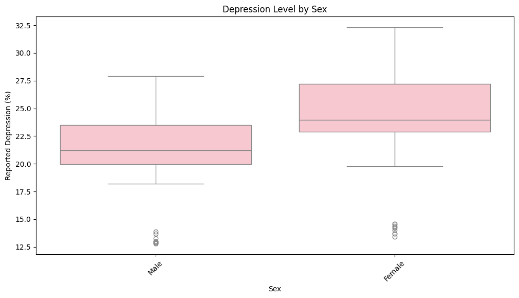

```python
dep_sex = depression_df[depression_df["Group"] == "By Sex"]

plt.figure(figsize = (12,6))
sns.boxplot(
    data = dep_sex,
    x = "Subgroup",
    y = "Value",
    color = "pink"
)
plt.xticks(rotation = 45)
plt.xlabel("Sex")
plt.ylabel("Reported Depression (%)")
plt.title("Depression Level by Sex")
plt.show()
```

```python
dep_numeric = depression_df.select_dtypes(include=["float64", "int64"])
depression_corr = dep_numeric.corr()
depression_corr
```

|  | Time Period | Value | Low CI | High CI |
| --- | --- | --- | --- | --- |
| Time Period | 1.000000 | -0.514304 | -0.487286 | -0.511005 |
| Value | -0.514304 | 1.000000 | 0.970605 | 0.967968 |
| Low CI | -0.487286 | 0.970605 | 1.000000 | 0.879301 |
| High CI | -0.511005 | 0.967968 | 0.879301 | 1.000000 |

```python
combined_df = df_2[df_2["Indicator"] == "Symptoms of Anxiety Disorder or Depressive Disorder"]
```

```python
comb_age = combined_df[combined_df["Group"] == "By Age"]

plt.figure(figsize=(12,6))
sns.boxplot(data=comb_age, x="Subgroup", y="Value", color="pink")
plt.xticks(rotation=45)
plt.title("Anxiety or Depression Symptoms by Age Group")
plt.xlabel("Age Group")
plt.ylabel("Reported (%)")

plt.show()
```

[output not shown]

```python
comb_sex = combined_df[combined_df["Group"] == "By Sex"]
plt.figure(figsize=(12,6))
sns.boxplot(data=comb_sex, x ="Subgroup", y ="Value", color ='pink')
plt.xticks(rotation = 45)
plt.title("Anxiety or Depression Symptoms by Sex")
plt.xlabel("Sex")
plt.ylabel("Reported (%)")
plt.show()
```

[output not shown]

### Time Series Analysis

```python
time_reference = (
    df_2[["Time Period", "Time Period Start Date", "Time Period End Date"]].drop_duplicates().sort_values("Time Period").reset_index(drop=True)
)

time_reference
```

|  | Time Period | Time Period Start Date | Time Period End Date |
| --- | --- | --- | --- |
| 0 | 1 | 2020-04-23 | 2020-05-05 |
| 1 | 1 | 2020-07-22 | 2020-08-18 |
| 2 | 1 | 2021-03-30 | 2021-04-13 |
| 3 | 1 | 2020-12-22 | 2021-01-05 |
| 4 | 1 | 2022-02-23 | 2022-03-01 |
| ... | ... | ... | ... |
| 77 | 68 | 2024-04-30 | 2024-05-27 |
| 78 | 69 | 2024-05-28 | 2024-06-24 |
| 79 | 70 | 2024-06-25 | 2024-07-22 |
| 80 | 71 | 2024-07-23 | 2024-08-19 |
| 81 | 72 | 2024-08-20 | 2024-09-16 |

82 rows × 3 columns

A reference table linking each time period to its dates.

```python
time_reference["Midpoint Date"] = (time_reference["Time Period Start Date"] + (time_reference["Time Period End Date"] - time_reference["Time Period Start Date"]) / 2
)
```

The original dataset included two date variables—Time Period Start Date and Time Period End Date—as well as a numeric Time Period. Because the “Time Period Label” column was removed earlier to eliminate redundancy, a separate reference table was created to define each time period. This table links each numeric period to its corresponding start and end dates. This reference is used to interpret changes in anxiety and depression indicators over time in the following time-series visualizations.

```python
df_2 = df_2[df_2["Group"] != "By Gender identity"]
```

```python
 hotpink = "#FF0074"
```

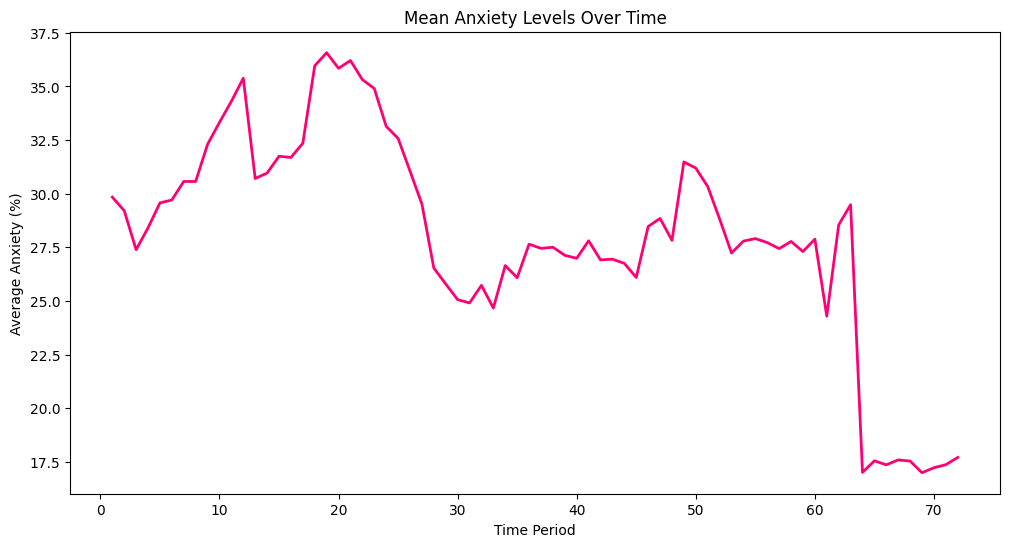

```python
anxiety_time = anxiety_df.groupby("Time Period")["Value"].mean().reset_index()

plt.figure(figsize = (12,6))
sns.lineplot(data = anxiety_time, x = "Time Period", y ="Value", color= hotpink, linewidth=2)

plt.title("Mean Anxiety Levels Over Time")
plt.xlabel("Time Period")
plt.ylabel("Average Anxiety (%)")
plt.show()
```

```python
anx_numeric = anxiety_df.select_dtypes(include=["float64", "int64"])
anxiety_corr = anx_numeric.corr()
anxiety_corr
```

|  | Time Period | Value | Low CI | High CI |
| --- | --- | --- | --- | --- |
| Time Period | 1.000000 | -0.506347 | -0.482386 | -0.506718 |
| Value | -0.506347 | 1.000000 | 0.976275 | 0.974880 |
| Low CI | -0.482386 | 0.976275 | 1.000000 | 0.903656 |
| High CI | -0.506718 | 0.974880 | 0.903656 | 1.000000 |

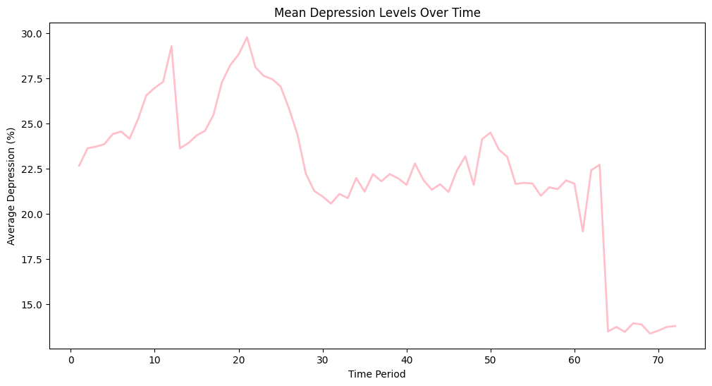

```python
dep_time = depression_df.groupby("Time Period")["Value"].mean().reset_index()

plt.figure(figsize=(12,6))
sns.lineplot(data = dep_time, x = "Time Period", y="Value", color = 'pink', linewidth = 2)

plt.title("Mean Depression Levels Over Time")
plt.xlabel("Time Period")
plt.ylabel("Average Depression (%)")
plt.show()
```

```python
dep_numeric = depression_df.select_dtypes(include=["float64", "int64"])
depression_corr = dep_numeric.corr()
depression_corr
```

|  | Time Period | Value | Low CI | High CI |
| --- | --- | --- | --- | --- |
| Time Period | 1.000000 | -0.514304 | -0.487286 | -0.511005 |
| Value | -0.514304 | 1.000000 | 0.970605 | 0.967968 |
| Low CI | -0.487286 | 0.970605 | 1.000000 | 0.879301 |
| High CI | -0.511005 | 0.967968 | 0.879301 | 1.000000 |

### Cleaning Data

```python
df_0.isna().sum()
```

```
Indicator                    0
Group                        0
State                        0
Subgroup                     0
Phase                        0
Time Period                  0
Time Period Label            0
Time Period Start Date       0
Time Period End Date         0
Value                      707
Low CI                     707
High CI                    707
Confidence Interval        707
Quartile Range            5777
dtype: int64
```

Because the missingness is systematic and reflects measurement limitations rather than random data loss, no imputation was performed. Analysis involving these estimation variables was restricted to observations with the available values.

```python
df_1 = pd.read_csv('Indicators_of_Anxiety_or_Depression_Based_on_Reported_Frequency_of_Symptoms_During_Last_7_Days.csv')
```

Making a copy of the dataframe was attempted, which appeared successful. Problems arose when trying to edit columns because the copy was actually a series. The CSV file was read twice. The second dataframe created from the original CSV file is meant to be edited; meanwhile, the first is kept intact for referencing.

```python
df_1.columns = df_1.columns.astype(str)
```

```python
print(df_1.columns.tolist())
```

```
['Indicator', 'Group', 'State', 'Subgroup', 'Phase', 'Time Period', 'Time Period Label', 'Time Period Start Date', 'Time Period End Date', 'Value', 'Low CI', 'High CI', 'Confidence Interval', 'Quartile Range']
```

```python
df_1.columns = df_1.columns.str.strip()
```

The data cleaning process begins with the removal of any leading and trailing whitespace characters, including spaces, tabs, and newlines. This assures that changes to the columns can be made because column names are recognized with no minor errors in spelling.

```python
df_1["Time Period Start Date"] = pd.to_datetime(df_1["Time Period Start Date"], errors = 'coerce')
df_1["Time Period End Date"] = pd.to_datetime(df_1["Time Period End Date"], errors = 'coerce')
```

The character entries in "Time Period Start Date" and "Time Period End Date" are converted to datetime objects. This allows for easier time series observations.

```python
df_1 = df_1.drop(columns=["Time Period Label"], errors="ignore")
```

The *Time Period Label* column was removed because it was redundant. The start and end dates for each period are already provided in separate date columns, and the *Time Period* variable numerically identifies each period. Since the label does not add new information on what these variables contain, it was dropped to streamline the dataset.

## Conclusions

There are limitations such as nonresponse bias and coverage issues. In other words, those who did not respond to mental health questions were excluded from the data set completely. Additionally, all respondents had access to either an email or a phone number, which was used to identify them to a geographical area. This limits the sampling to individuals with familiarity with technology and internet access. If emails or phone numbers were not updated geographically, then state information could be inaccurate. For this reason, the geographical analysis was not explored in this report.

## Resources

- [Data.gov](https://catalog.data.gov/dataset/indicators-of-anxiety-or-depression-based-on-reported-frequency-of-symptoms-during-last-7-)
- [CSV File](https://catalog.data.gov/dataset/indicators-of-anxiety-or-depression-based-on-reported-frequency-of-symptoms-during-last-7-/resource/fd15ea5e-2966-480d-aaf3-30bb372f8ba3)
- [Kaggle](https://www.kaggle.com/datasets/melissamonfared/indicators-of-anxiety-or-depression/data)
- [CDC Data Post](https://data.cdc.gov/National-Center-for-Health-Statistics/Indicators-of-Anxiety-or-Depression-Based-on-Repor/8pt5-q6wp/about_data)
- [Anxiety and Depression Household Pulse Survey](https://www.cdc.gov/nchs/covid19/pulse/mental-health.htm)
- [2020 HPS Non-Bias Report](https://www2.census.gov/programs-surveys/demo/technical-documentation/hhp/2020_HPS_NR_Bias_Report-final.pdf)
- [Household Pulse Survey: Measuring Emergent Social and Economic Matters Facing U.S. Households](https://www.census.gov/data/experimental-data-products/household-pulse-survey.html)